# Reproducible Research: Peer Assessment 1

## Loading and preprocessing the data

Dataset is in the same working directory called “activity.zip”.

**0. If the file has not been unzipped before, unzip it.**

```r
if (!file.exists("activity.csv"))
    {
        unzip("activity.zip")
    }
```

**1. Load the data into a variable called dataActivity.**

```r
dataActivity <- read.csv("activity.csv")
```

**2. Process/transform the data (if necessary) into a format suitable for your analysis (convert the date from Factor to Date).**

```r
dataActivity$date <- as.Date(dataActivity$date, "%Y-%m-%d")
```

## What is mean total number of steps taken per day?

**0. Aggregate the data by summing up the steps by date**

```r
dataStepsByDate<-aggregate(steps~date,data=dataActivity,sum,na.rm=TRUE)
```

**1. Make a histogram of the total number of steps taken each day**

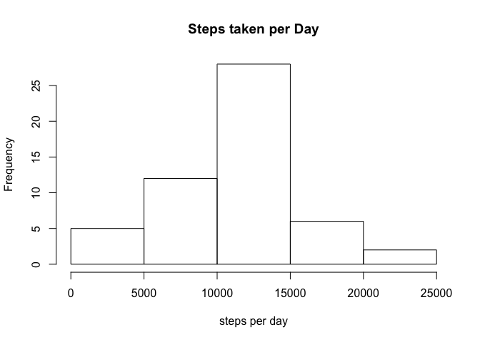

```r
hist(dataStepsByDate$steps, main = "Steps taken per Day", xlab = "steps per day")
```

**2. Calculate and report the mean and median total number of steps taken per day**

```r
mean(dataStepsByDate$steps)
```

```
## [1] 10766
```

```r
median(dataStepsByDate$steps)
```

```
## [1] 10765
```

Thus, the **mean** total number of steps taken per day is 1.0766 × 10<sup>4</sup>. The **median** total number of steps taken per day is 10765.

## What is the average daily activity pattern?

```r
dataStepsByInterval<-aggregate(steps~interval,data=dataActivity,mean,na.rm=TRUE)
```

**1. Make a time series plot (i.e. type = “l”) of the 5-minute interval (x-axis) and the average number of steps taken, averaged across all days (y-axis)**

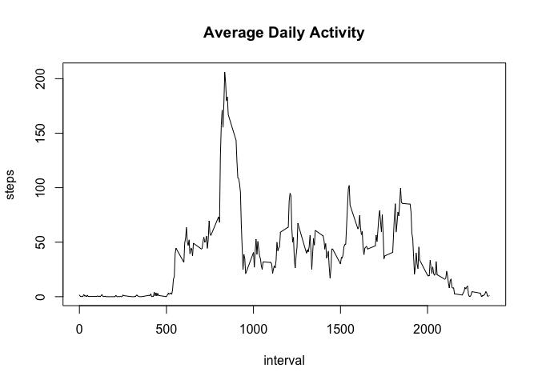

```r
with(dataStepsByInterval, plot(steps~interval, type="l", main = "Average Daily Activity"), xlab = "5-minute Interval", ylab = "Avergae Steps")
```

**2. Which 5-minute interval, on average across all the days in the dataset, contains the maximum number of steps?**

```r
dataStepsByInterval[which.max(dataStepsByInterval$steps), ]$interval
```

```
## [1] 835
```